# TripAdvisor Review

### How can we group the customer feedbacks.

- TripAdvisor, Inc. is an American travel and restaurant website company that shows hotel and restaurant reviews, accommodation bookings and other travel-related content.It also includes interactive travel forums.
- Headquartered in Needham, Massachusetts, TripAdvisor is the largest travel website in the world, with more than 315 million reviewers (active and inactive) and over 500 million reviews of hotels, restaurants, attractions and other travel-related businesses. TripAdvisor was an early adopter of user-generated content. The website services are free to users, who provide most of the content, and the website is supported by a hotel booking facility and an advertising business model.
- This data set is populated by crawling TripAdvisor.com.
- Reviews on destinations in 10 categories mentioned across East Asia are considered. Each traveler rating is mapped as
- Excellent (4)
- Very Good (3)
- Average (2)
- Poor (1)
- Terrible (0)

And average rating is used against each category per user.

- All of us that use Trip Advisor gets good advice on where we can eat, sleep, go on adventure etc. So you are helping others get a good experience around the world which is a great benefit! Besides that the feeling of knowing that you've help others is always nice, which is why I often review restaurants on Trip Advisor.
- Now the company wants to use this data to undestand who are having similar reviews on the following categories. Can we help them?

### Attribute Information:

- Attribute 1 : Unique user id
- Attribute 2 : Average user feedback on art galleries
- Attribute 3 : Average user feedback on dance clubs
- Attribute 4 : Average user feedback on juice bars
- Attribute 5 : Average user feedback on restaurants
- Attribute 6 : Average user feedback on museums
- Attribute 7 : Average user feedback on resorts
- Attribute 8 : Average user feedback on parks/picnic spots
- Attribute 9 : Average user feedback on beaches
- Attribute 10 : Average user feedback on theaters
- Attribute 11 : Average user feedback on religious institution

## Importing LIbraries and Understanding Data

```python
import numpy as np
import pandas as pd
import matplotlib.pyplot as plt
import seaborn as sns
%matplotlib inline

import warnings
warnings.filterwarnings("ignore")
```

## Read the Data

```python
df = pd.read_csv("tripadvisor_review.csv")
```

```python
del df['User ID']
```

```python
df.head()
```

|  | Category 1 | Category 2 | Category 3 | Category 4 | Category 5 | Category 6 | Category 7 | Category 8 | Category 9 | Category 10 |
| --- | --- | --- | --- | --- | --- | --- | --- | --- | --- | --- |
| 0 | 0.93 | 1.8 | 2.29 | 0.62 | 0.80 | 2.42 | 3.19 | 2.79 | 1.82 | 2.42 |
| 1 | 1.02 | 2.2 | 2.66 | 0.64 | 1.42 | 3.18 | 3.21 | 2.63 | 1.86 | 2.32 |
| 2 | 1.22 | 0.8 | 0.54 | 0.53 | 0.24 | 1.54 | 3.18 | 2.80 | 1.31 | 2.50 |
| 3 | 0.45 | 1.8 | 0.29 | 0.57 | 0.46 | 1.52 | 3.18 | 2.96 | 1.57 | 2.86 |
| 4 | 0.51 | 1.2 | 1.18 | 0.57 | 1.54 | 2.02 | 3.18 | 2.78 | 1.18 | 2.54 |

```python
df.shape
```

```
(980, 10)
```

## Lets check the data type

```python
df.dtypes
```

```
Category 1     float64
Category 2     float64
Category 3     float64
Category 4     float64
Category 5     float64
Category 6     float64
Category 7     float64
Category 8     float64
Category 9     float64
Category 10    float64
dtype: object
```

## Let's check the summary of data

```python
df.info()
```

```
<class 'pandas.core.frame.DataFrame'>
RangeIndex: 980 entries, 0 to 979
Data columns (total 10 columns):
 #   Column       Non-Null Count  Dtype
---  ------       --------------  -----
 0   Category 1   980 non-null    float64
 1   Category 2   980 non-null    float64
 2   Category 3   980 non-null    float64
 3   Category 4   980 non-null    float64
 4   Category 5   980 non-null    float64
 5   Category 6   980 non-null    float64
 6   Category 7   980 non-null    float64
 7   Category 8   980 non-null    float64
 8   Category 9   980 non-null    float64
 9   Category 10  980 non-null    float64
dtypes: float64(10)
memory usage: 76.7 KB
```

```python
df.describe()
```

|  | Category 1 | Category 2 | Category 3 | Category 4 | Category 5 | Category 6 | Category 7 | Category 8 | Category 9 | Category 10 |
| --- | --- | --- | --- | --- | --- | --- | --- | --- | --- | --- |
| count | 980.000000 | 980.000000 | 980.000000 | 980.000000 | 980.000000 | 980.000000 | 980.000000 | 980.000000 | 980.000000 | 980.000000 |
| mean | 0.893194 | 1.352612 | 1.013306 | 0.532500 | 0.939735 | 1.842898 | 3.180939 | 2.835061 | 1.569439 | 2.799224 |
| std | 0.326912 | 0.478280 | 0.788607 | 0.279731 | 0.437430 | 0.539538 | 0.007824 | 0.137505 | 0.364629 | 0.321380 |
| min | 0.340000 | 0.000000 | 0.130000 | 0.150000 | 0.060000 | 0.140000 | 3.160000 | 2.420000 | 0.740000 | 2.140000 |
| 25% | 0.670000 | 1.080000 | 0.270000 | 0.410000 | 0.640000 | 1.460000 | 3.180000 | 2.740000 | 1.310000 | 2.540000 |
| 50% | 0.830000 | 1.280000 | 0.820000 | 0.500000 | 0.900000 | 1.800000 | 3.180000 | 2.820000 | 1.540000 | 2.780000 |
| 75% | 1.020000 | 1.560000 | 1.572500 | 0.580000 | 1.200000 | 2.200000 | 3.180000 | 2.910000 | 1.760000 | 3.040000 |
| max | 3.220000 | 3.640000 | 3.620000 | 3.440000 | 3.300000 | 3.760000 | 3.210000 | 3.390000 | 3.170000 | 3.660000 |

## Total Unique Value

```python
df.nunique()
```

```
Category 1      84
Category 2      73
Category 3     195
Category 4      91
Category 5      87
Category 6     135
Category 7       6
Category 8      68
Category 9      65
Category 10     56
dtype: int64
```

## Missing Value

```python
df.isnull().sum()
```

```
Category 1     0
Category 2     0
Category 3     0
Category 4     0
Category 5     0
Category 6     0
Category 7     0
Category 8     0
Category 9     0
Category 10    0
dtype: int64
```

## Data Visualization

### Correlation matrix

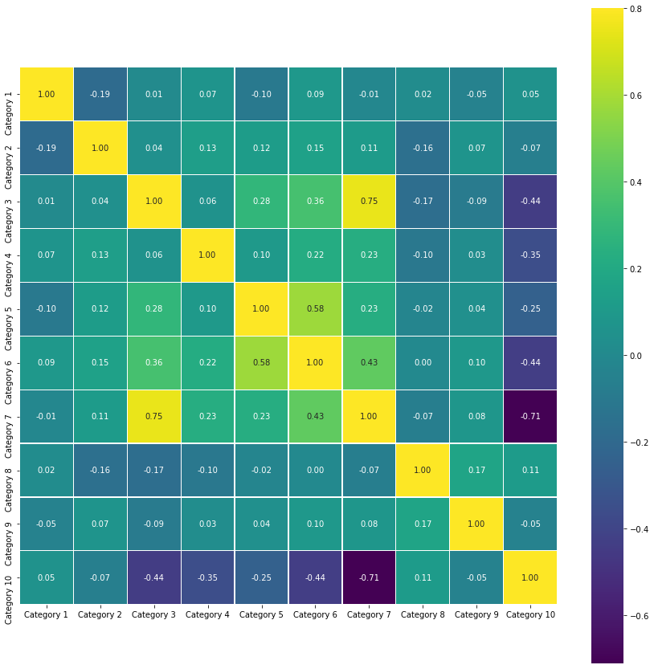

```python
colormap = plt.cm.viridis
cor = df.corr()
plt.figure(figsize=(15,15))
sns.heatmap(cor,vmax=0.8,cmap=colormap,annot=True,fmt='.2f',square=True,annot_kws={'size':10},linecolor='white',linewidths=0.1)
```

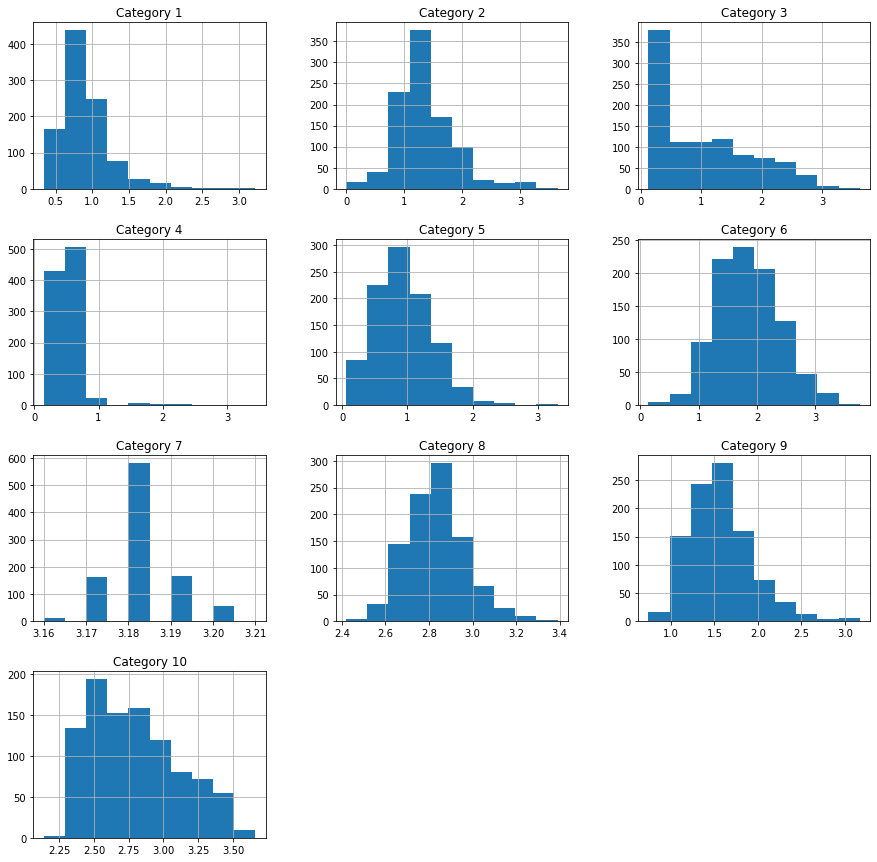

```python
df.hist(figsize=(15,15))
plt.show()
```

```python
samples = df.values
```

```python
from sklearn.cluster import KMeans
num_of_clusters = range(1,10)
wcss = []

for k in num_of_clusters:

    # create a Kmeans class instance with k clusters
    model = KMeans(n_clusters=k, random_state=15)

    # build the model using the data
    model.fit(samples)

    # append the inertia (wcss) to the list named "wccss"
    wcss.append(model.inertia_)
```

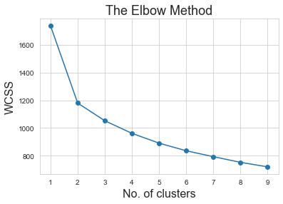

```python
sns.set_style("whitegrid")
plt.plot(num_of_clusters,wcss, '-o')
plt.title('The Elbow Method',  fontsize = 18)
plt.xlabel('No. of clusters', fontsize=16)
plt.ylabel('WCSS', fontsize=16)
```

```python
kmeans = KMeans(n_clusters=3)
kmeans.fit(samples)
labels = kmeans.fit_predict(samples)

kmeans.cluster_centers_
```

```
array([[0.89806897, 1.48248276, 0.71062069, 0.61324138, 1.17503448,
        2.23910345, 3.17965517, 2.85965517, 1.60637931, 2.75072414],
       [0.87641304, 1.39246377, 2.07434783, 0.56376812, 1.12753623,
        2.08318841, 3.18913043, 2.79673913, 1.52978261, 2.58565217],
       [0.90096618, 1.23507246, 0.51797101, 0.45509662, 0.64971014,
        1.40516908, 3.17637681, 2.84338164, 1.57      , 2.97557971]])
```

```python
from sklearn.cluster import KMeans
from sklearn.metrics import silhouette_score

num_of_clusters = list(range(2,7))
silhouette_score_list = []

for k in num_of_clusters:
    # Create a KMeans class instance with k clusters
    model = KMeans(n_clusters=k, random_state=15)

    # Build the model using the data and predict the clusters
    clusters_labels = model.fit_predict(samples)

    silhouette_score_list.append(silhouette_score(samples,clusters_labels))
```

```python
num_of_clusters.insert(0,1)
silhouette_score_list.insert(0,0)
```

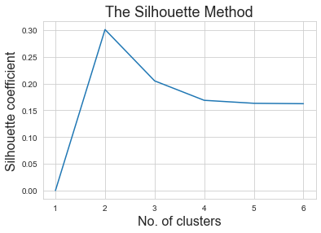

```python
plt.plot(num_of_clusters,silhouette_score_list)
plt.title('The Silhouette Method',  fontsize = 18)
plt.xlabel('No. of clusters',  fontsize = 16)
plt.ylabel('Silhouette coefficient',  fontsize = 16)
```

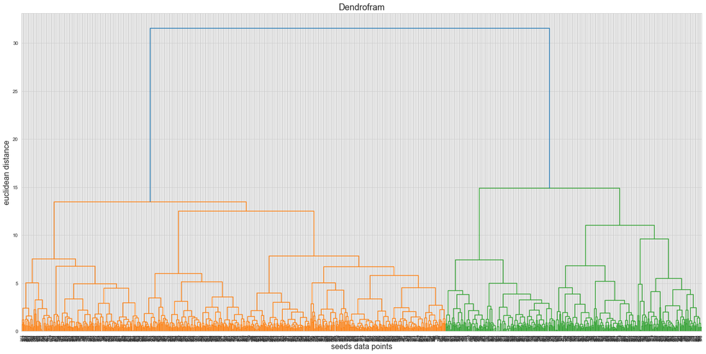

```python
import scipy.cluster.hierarchy as sch
plt.figure(figsize=(25,12))
sch.dendrogram(sch.linkage(samples, method='ward'));
plt.title('Dendrofram',  fontsize = 18)
plt.xlabel('seeds data points',  fontsize = 16)
plt.xticks(rotation = 90, fontsize = 8)
plt.ylabel('euclidean distance',  fontsize = 16)
plt.show()
```